# COM747 Week 8: Clustering and Principal Component Analysis

Lecture demonstrations and complete seminar solutions

> **How to use this notebook.** Part A is the “K-Means Clustering” demonstration notebook (students’ study hours and exam scores), tidied so it knits. Part B is the complete k-means tutorial on `mtcars` (`Exercise(5).pdf`, first half), Part C hierarchical clustering, and Part D the PCA tutorial on `iris` (second half). Lines in the original sheets that don’t run as written are flagged in orange boxes. Everything uses built-in data, so no files are needed.

```r
library(cluster)      # clusplot()
library(corrplot)     # corrplot()
library(ggplot2)
library(ggfortify)    # autoplot() for prcomp objects
```

# Part A: k-means from first principles

## A1. Simulated students

```r
set.seed(123)                                   # everyone gets the same random numbers
study_hours <- c(rnorm(30, mean = 5,  sd = 1), rnorm(30, mean = 10, sd = 1))
exam_scores <- c(rnorm(30, mean = 60, sd = 5), rnorm(30, mean = 85, sd = 5))
students <- data.frame(study_hours, exam_scores)
head(students)                                  # View() opens a window; head() works in a knitted file
```

```
##   study_hours exam_scores
## 1    4.439524    61.89820
## 2    4.769823    57.48838
## 3    6.558708    58.33396
## 4    5.070508    54.90712
## 5    5.129288    54.64104
## 6    6.715065    61.51764
```

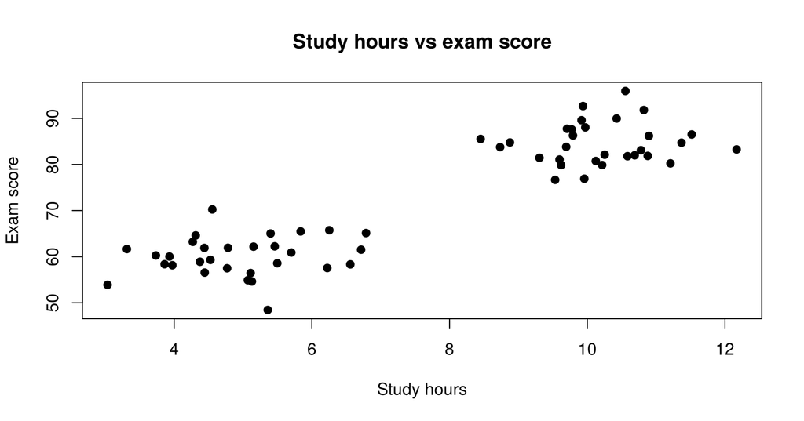

```r
plot(students, pch = 19, main = "Study hours vs exam score",
     xlab = "Study hours", ylab = "Exam score")
```

**Ask:** How many groups do you see? Two: low hours/low scores and high hours/high scores. k-means should find them without being told which is which.

## A2. The algorithm written out by hand

Before calling `kmeans()`, here are the four steps of the lecture as plain R, so the “black box” is visible.

```r
my_kmeans <- function(X, k, max_iter = 20, seed = 1) {
  set.seed(seed)
  X <- as.matrix(X)
  centres <- X[sample(nrow(X), k), , drop = FALSE]      # step 1: k random points as centres
  for (it in 1:max_iter) {
    # step 2: squared distance from every point to every centre, then pick the nearest
    d <- sapply(1:k, function(j) rowSums((X - matrix(centres[j, ], nrow(X), ncol(X), byrow = TRUE))^2))
    cluster <- max.col(-d)                               # column with the smallest distance
    # step 3: move each centre to the mean of its members
    new_centres <- t(sapply(1:k, function(j) colMeans(X[cluster == j, , drop = FALSE])))
    # step 4: stop when the centres stop moving
    if (max(abs(new_centres - centres)) < 1e-8) break
    centres <- new_centres
  }
  list(cluster = cluster, centers = centres, iterations = it,
       tot.withinss = sum((X - centres[cluster, ])^2))
}

mine <- my_kmeans(students, k = 2)
mine$iterations
```

```
## [1] 2
```

```r
mine$centers
```

```
##      study_hours exam_scores
## [1,]   10.178338    84.53056
## [2,]    4.952896    60.12210
```

## A3. The built-in `kmeans()`

```r
set.seed(123)
kmeans_result <- kmeans(students, centers = 2, nstart = 25)
kmeans_result$centers
```

```
##   study_hours exam_scores
## 1   10.178338    84.53056
## 2    4.952896    60.12210
```

```r
kmeans_result$size
```

```
## [1] 30 30
```

```r
table(mine = mine$cluster, kmeans = kmeans_result$cluster)   # same groups (labels 1/2 may swap)
```

```
##     kmeans
## mine  1  2
##    1 30  0
##    2  0 30
```

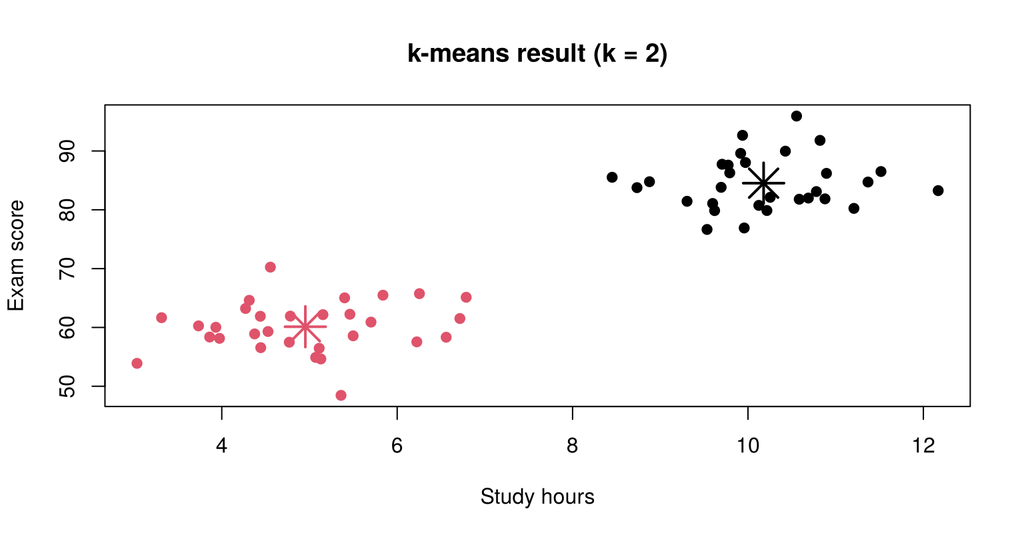

```r
plot(students, col = kmeans_result$cluster, pch = 19,
     main = "k-means result (k = 2)", xlab = "Study hours", ylab = "Exam score")
points(kmeans_result$centers, col = 1:2, pch = 8, cex = 3, lwd = 2)   # stars = centroids
```

**Scaling.** Exam score has a spread of about 13 and study hours about 2.7, so distances here are mostly driven by the score. It works because the two groups differ on both, but in general use `scale()` first (see Part B).

## A4. Too many clusters

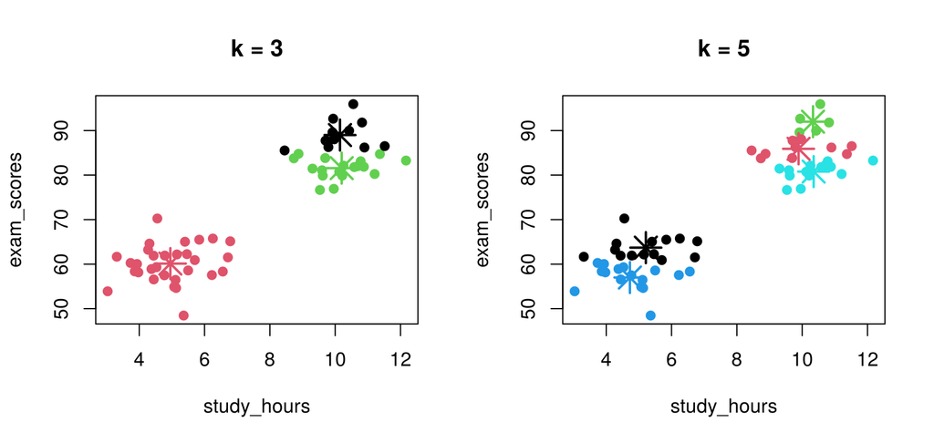

```r
par(mfrow = c(1, 2))
set.seed(123); kmeans_result3 <- kmeans(students, centers = 3, nstart = 25)
plot(students, col = kmeans_result3$cluster, pch = 19, main = "k = 3")
points(kmeans_result3$centers, col = 1:3, pch = 8, cex = 2.5, lwd = 2)

set.seed(123); kmeans_result5 <- kmeans(students, centers = 5, nstart = 25)
plot(students, col = kmeans_result5$cluster, pch = 19, main = "k = 5")
points(kmeans_result5$centers, col = 1:5, pch = 8, cex = 2.5, lwd = 2)
```

```r
par(mfrow = c(1, 1))
```

**Bug in the original notebook:** the k = 5 plot drew `kmeans_result3$centers` (only 3 stars). It should be `kmeans_result5$centers`, as above.

k-means always returns exactly k groups, even when the data has fewer natural groups: it simply splits a real group in half.

## A5. Elbow method

```r
set.seed(123)
wss <- sapply(1:8, function(k) kmeans(students, centers = k, nstart = 25)$tot.withinss)
round(wss)
```

```
## [1] 10539  1193   795   458   358   267   211   172
```

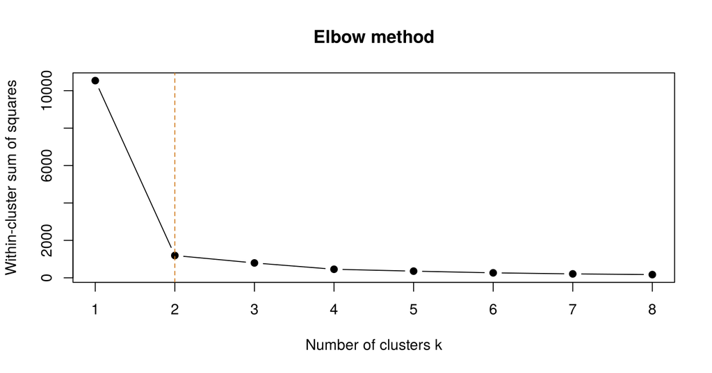

```r
plot(1:8, wss, type = "b", pch = 19, xlab = "Number of clusters k",
     ylab = "Within-cluster sum of squares", main = "Elbow method")
abline(v = 2, lty = 2, col = "#d0791a")
```

The total within-cluster sum of squares (WSS) always falls as k grows (k = n gives 0). We look for the **elbow**, where adding a cluster stops buying much. Here it is clearly at k = 2.

## A6. Iris without the labels

```r
iris_data <- iris[, -5]                       # drop Species: pretend we don't know it
set.seed(123)
iris_kmeans <- kmeans(scale(iris_data), centers = 3, nstart = 25)
table(cluster = iris_kmeans$cluster, species = iris$Species)
```

```
##        species
## cluster setosa versicolor virginica
##       1     50          0         0
##       2      0         39        14
##       3      0         11        36
```

**Ask:** Setosa forms its own cluster perfectly. Why do versicolor and virginica get mixed? (Their measurements overlap. Clustering finds structure in the features; it can’t find a difference the features don’t show.)

# Part B: k-means on mtcars (seminar tutorial)

## B1. Select and standardise the variables

```r
mtcars <- datasets::mtcars                 # a fresh copy of the built-in data
# ?mtcars describes the 11 variables
mtcarsNew <- mtcars[, c(1, 2, 4)]          # 1 = mpg, 2 = cyl, 4 = hp
head(mtcarsNew)
```

```
##                    mpg cyl  hp
## Mazda RX4         21.0   6 110
## Mazda RX4 Wag     21.0   6 110
## Datsun 710        22.8   4  93
## Hornet 4 Drive    21.4   6 110
## Hornet Sportabout 18.7   8 175
## Valiant           18.1   6 105
```

```r
mtcarsNew <- scale(mtcarsNew)              # z-scores: (x - mean) / sd for each column
round(colMeans(mtcarsNew), 10)             # every mean is now 0
```

```
## mpg cyl  hp
##   0   0   0
```

```r
apply(mtcarsNew, 2, sd)                    # and every sd is 1
```

```
## mpg cyl  hp
##   1   1   1
```

## B2. Box plots: raw against scaled

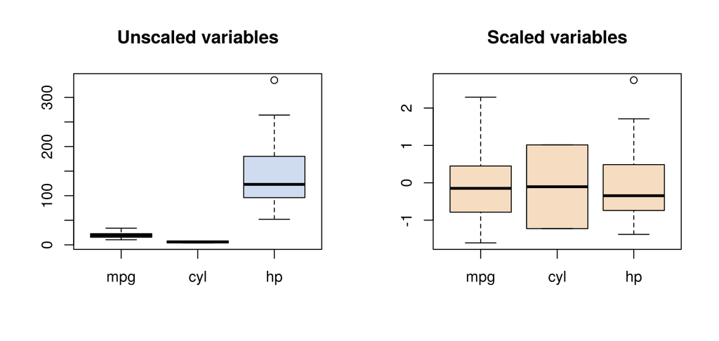

```r
par(mfrow = c(1, 2))
boxplot(mtcars[, c(1, 2, 4)], main = "Unscaled variables", col = "#cfdcf0")
boxplot(mtcarsNew, main = "Scaled variables", col = "#f6dcc0")
```

```r
par(mfrow = c(1, 1))
```

Unscaled, `hp` (52 to 335) dwarfs `mpg` (10 to 34) and `cyl` (4 to 8), so distance would be almost entirely horsepower. After scaling each variable has the same spread: “not perfect, but a more equal playing field”.

## B3. k-means with k = 3

```r
set.seed(123)
kMeansClust <- kmeans(mtcarsNew, centers = 3, iter.max = 10, nstart = 25)
# centers  = number of clusters
# iter.max = maximum number of assign/update rounds
# nstart   = try 25 random starts and keep the best (lowest WSS)
kMeansClust$cluster          # cluster for each car
```

```
##           Mazda RX4       Mazda RX4 Wag          Datsun 710      Hornet 4 Drive
##                   1                   1                   1                   1
##   Hornet Sportabout             Valiant          Duster 360           Merc 240D
##                   2                   1                   2                   3
##            Merc 230            Merc 280           Merc 280C          Merc 450SE
##                   1                   1                   1                   2
##          Merc 450SL         Merc 450SLC  Cadillac Fleetwood Lincoln Continental
##                   2                   2                   2                   2
##   Chrysler Imperial            Fiat 128         Honda Civic      Toyota Corolla
##                   2                   3                   3                   3
##       Toyota Corona    Dodge Challenger         AMC Javelin          Camaro Z28
##                   1                   2                   2                   2
##    Pontiac Firebird           Fiat X1-9       Porsche 914-2        Lotus Europa
##                   2                   3                   3                   3
##      Ford Pantera L        Ferrari Dino       Maserati Bora          Volvo 142E
##                   2                   1                   2                   1
```

```r
kMeansClust$size             # cars per cluster
```

```
## [1] 11 14  7
```

```r
round(kMeansClust$centers, 2)   # centroids in z-score units
```

```
##     mpg   cyl    hp
## 1  0.09 -0.51 -0.48
## 2 -0.83  1.01  0.91
## 3  1.52 -1.22 -1.07
```

The centres are hard to read in z-scores, so put them back into original units:

```r
aggregate(mtcars[, c(1, 2, 4)], by = list(cluster = kMeansClust$cluster), mean)
```

```
##   cluster      mpg      cyl        hp
## 1       1 20.60909 5.272727 113.63636
## 2       2 15.10000 8.000000 209.21429
## 3       3 29.25714 4.000000  73.57143
```

## B4. Name the clusters

```r
mtcars$clusterLabel <- kMeansClust$cluster

# Name each cluster from its profile rather than its number, because k-means
# numbers clusters arbitrarily (a different seed can swap them).
prof <- aggregate(mtcars[, c(1, 2, 4)], by = list(cluster = kMeansClust$cluster), mean)
name_of <- character(3)
name_of[which.max(prof$mpg)] <- "Economical, less powerful"
name_of[which.max(prof$hp)]  <- "Fast but expensive to run"
name_of[name_of == ""]       <- "Average car"
mtcars$clusterName <- factor(name_of[mtcars$clusterLabel])
table(mtcars$clusterName)
```

```
##
##               Average car Economical, less powerful Fast but expensive to run
##                        11                         7                        14
```

```r
split(rownames(mtcars), mtcars$clusterName)
```

```
## $`Average car`
##  [1] "Mazda RX4"      "Mazda RX4 Wag"  "Datsun 710"     "Hornet 4 Drive"
##  [5] "Valiant"        "Merc 230"       "Merc 280"       "Merc 280C"
##  [9] "Toyota Corona"  "Ferrari Dino"   "Volvo 142E"
##
## $`Economical, less powerful`
## [1] "Merc 240D"      "Fiat 128"       "Honda Civic"    "Toyota Corolla"
## [5] "Fiat X1-9"      "Porsche 914-2"  "Lotus Europa"
##
## $`Fast but expensive to run`
##  [1] "Hornet Sportabout"   "Duster 360"          "Merc 450SE"
##  [4] "Merc 450SL"          "Merc 450SLC"         "Cadillac Fleetwood"
##  [7] "Lincoln Continental" "Chrysler Imperial"   "Dodge Challenger"
## [10] "AMC Javelin"         "Camaro Z28"          "Pontiac Firebird"
## [13] "Ford Pantera L"      "Maserati Bora"
```

The sheet says “try to also add these to the Iris data frame”. It means the **mtcars** data frame, which is what we did here.

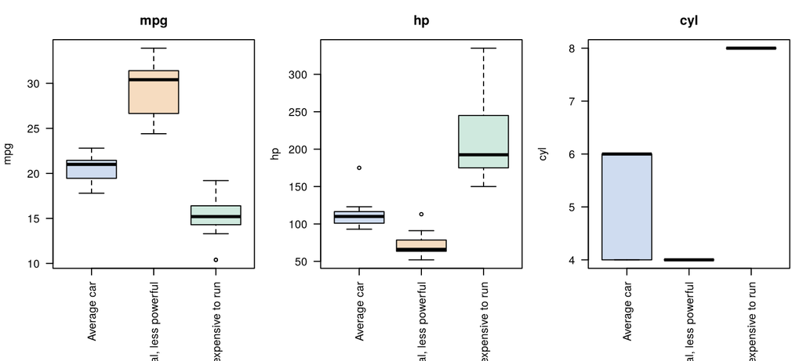

```r
par(mfrow = c(1, 3), mar = c(7, 4, 3, 1))
boxplot(mpg ~ clusterName, data = mtcars, las = 2, xlab = "", main = "mpg", col = c("#cfdcf0","#f6dcc0","#cfe9de"))
boxplot(hp  ~ clusterName, data = mtcars, las = 2, xlab = "", main = "hp",  col = c("#cfdcf0","#f6dcc0","#cfe9de"))
boxplot(cyl ~ clusterName, data = mtcars, las = 2, xlab = "", main = "cyl", col = c("#cfdcf0","#f6dcc0","#cfe9de"))
```

```r
par(mfrow = c(1, 1), mar = c(5, 4, 4, 2))
```

## B5. Elbow plot with `wssplot()`

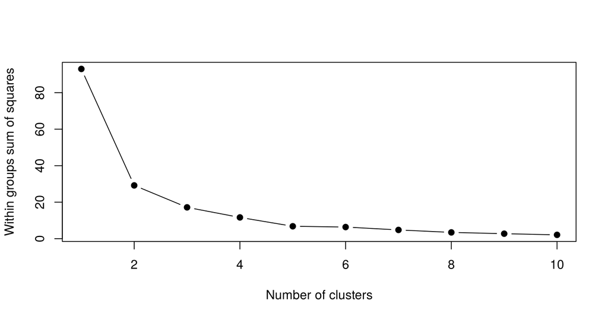

```r
# The function must be DEFINED before it is called. (The sheet shows the call first.)
# Code adapted from R in Action, r-bloggers 2013.
wssplot <- function(data, nc = 15, seed = 12) {
  wss <- (nrow(data) - 1) * sum(apply(data, 2, var))   # k = 1: total sum of squares
  for (i in 2:nc) {
    set.seed(seed)
    wss[i] <- sum(kmeans(data, centers = i)$withinss)  # k = i
  }
  plot(1:nc, wss, type = "b", pch = 19, xlab = "Number of clusters",
       ylab = "Within groups sum of squares")
  invisible(wss)            # return the values too, so wss <- wssplot(...) is useful
}

wss <- wssplot(data = mtcarsNew, nc = 10)
```

```r
round(wss, 2)
```

```
##  [1] 93.00 29.18 17.16 11.64  6.80  6.37  4.79  3.43  2.73  2.09
```

**Two fixes.** (1) `wssplot` is defined before the call. (2) The original function only plots, so `wss <- wssplot(...)` stored `NULL`; adding `invisible(wss)` returns the numbers. Note also that inside `wssplot` `kmeans()` uses a single random start, so on other data the curve can wobble upwards when a run gets stuck (see B7). Adding `nstart = 25` inside the function avoids that.

## B6. Visualise clusters with `clusplot()`

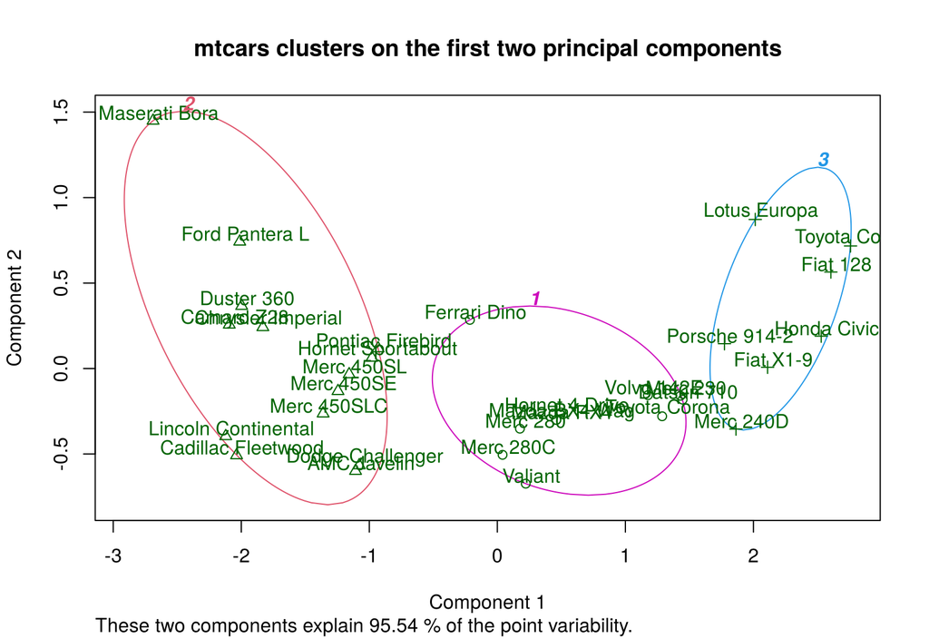

```r
clusplot(mtcarsNew, kMeansClust$cluster, color = TRUE, shade = FALSE,
         labels = 2, lines = 0, main = "mtcars clusters on the first two principal components")
```

`clusplot` draws the cars on the first two **principal components** (Part D): “These two components explain 95.54 % of the point variability”. With 3 variables, two components lose very little. `labels = 2` labels points and ellipses; `labels = 3` only points; `labels = 5` ellipses and identified points; `lines = 0` hides the lines between cluster centres.

## B7. How stable is the solution?

```r
# Run k-means with one random start, 20 times, and see how much the WSS varies.
w1  <- sapply(1:20, function(s) { set.seed(s); kmeans(mtcarsNew, 3, nstart = 1)$tot.withinss })
w25 <- sapply(1:20, function(s) { set.seed(s); kmeans(mtcarsNew, 3, nstart = 25)$tot.withinss })
summary(w1); summary(w25)
```

```
##    Min. 1st Qu.  Median    Mean 3rd Qu.    Max.
##   17.16   17.16   17.16   17.55   18.42   18.42
```

```
##    Min. 1st Qu.  Median    Mean 3rd Qu.    Max.
##   17.16   17.16   17.16   17.16   17.16   17.16
```

With a single start, k-means sometimes stops in a worse local optimum. `nstart = 25` almost always finds the best one.

# Part C: Hierarchical clustering

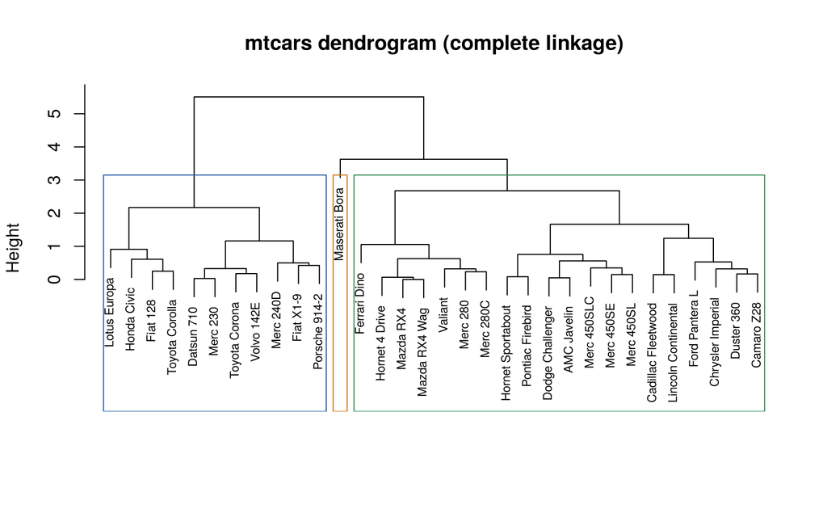

```r
d  <- dist(mtcarsNew)                     # Euclidean distances between all pairs of cars
hc <- hclust(d, method = "complete")      # complete linkage: distance between farthest members
plot(hc, cex = 0.7, main = "mtcars dendrogram (complete linkage)", xlab = "", sub = "")
rect.hclust(hc, k = 3, border = c("#2b5fa6", "#d0791a", "#2e8b57"))
```

```r
hc3 <- cutree(hc, k = 3)                  # or cutree(hc, h = 3.2) to cut at a height
table(hierarchical = hc3, kmeans = kMeansClust$cluster)
```

```
##             kmeans
## hierarchical  1  2  3
##            1  7 13  0
##            2  4  0  7
##            3  0  1  0
```

**Ask:** Why don’t the two methods agree? Complete linkage puts Maserati Bora, the most extreme car, in a cluster of its own, while k-means always balances clusters around means. Different methods have different ideas of a “cluster”, so it’s good practice to compare them.

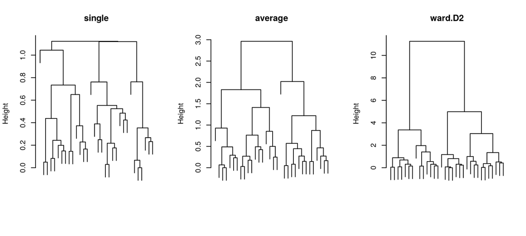

```r
par(mfrow = c(1, 3))
for (m in c("single", "average", "ward.D2")) plot(hclust(d, method = m), labels = FALSE, main = m, xlab = "", sub = "")
```

```r
par(mfrow = c(1, 1))
```

Single linkage chains points together; Ward’s method gives compact clusters most like k-means.

# Part D: PCA on iris (seminar tutorial)

## D1. Explore the data

```r
table(iris$Species)       # 3 species, 50 flowers each
```

```
##
##     setosa versicolor  virginica
##         50         50         50
```

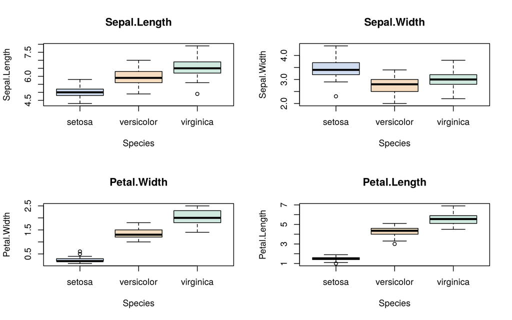

```r
par(mfrow = c(2, 2))
cols <- c("#cfdcf0", "#f6dcc0", "#cfe9de")
boxplot(Sepal.Length ~ Species, data = iris, main = "Sepal.Length", col = cols)
boxplot(Sepal.Width  ~ Species, data = iris, main = "Sepal.Width",  col = cols)
boxplot(Petal.Width  ~ Species, data = iris, main = "Petal.Width",  col = cols)
boxplot(Petal.Length ~ Species, data = iris, main = "Petal.Length", col = cols)
```

```r
par(mfrow = c(1, 1))
```

Petal length and width separate the species best; sepal width overlaps most.

## D2. Correlation matrix

```r
CM <- cor(iris[, 1:4])
round(CM, 2)
```

```
##              Sepal.Length Sepal.Width Petal.Length Petal.Width
## Sepal.Length         1.00       -0.12         0.87        0.82
## Sepal.Width         -0.12        1.00        -0.43       -0.37
## Petal.Length         0.87       -0.43         1.00        0.96
## Petal.Width          0.82       -0.37         0.96        1.00
```

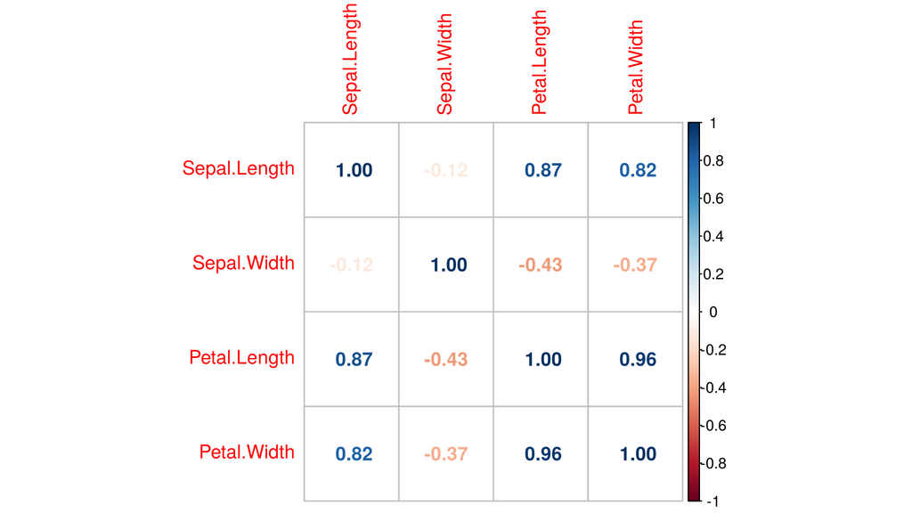

```r
corrplot(CM, method = "number")
```

Petal length, petal width and sepal length are strongly correlated (0.82 to 0.96): they carry much the same information. That redundancy is what PCA compresses.

## D3. Run the PCA

```r
irisPCA <- prcomp(iris[, 1:4], center = TRUE, scale. = TRUE)
# center = TRUE  subtracts each column mean
# scale. = TRUE  divides by each column sd (same idea as scale() for k-means)
summary(irisPCA)
```

```
## Importance of components:
##                           PC1    PC2     PC3     PC4
## Standard deviation     1.7084 0.9560 0.38309 0.14393
## Proportion of Variance 0.7296 0.2285 0.03669 0.00518
## Cumulative Proportion  0.7296 0.9581 0.99482 1.00000
```

```r
round(irisPCA$rotation, 3)     # loadings: how much each variable contributes to each PC
```

```
##                 PC1    PC2    PC3    PC4
## Sepal.Length  0.521 -0.377  0.720  0.261
## Sepal.Width  -0.269 -0.923 -0.244 -0.124
## Petal.Length  0.580 -0.024 -0.142 -0.801
## Petal.Width   0.565 -0.067 -0.634  0.524
```

PC1 explains 73.0 % of the variance and PC2 22.9 %, so two components keep 95.8 % of the information in four variables.

**What’s inside.** The components are the eigenvectors of the correlation matrix and the variances are its eigenvalues. You can check: `eigen(CM)$values` equals `irisPCA$sdev^2`.

```r
round(eigen(CM)$values, 4)
```

```
## [1] 2.9185 0.9140 0.1468 0.0207
```

```r
round(irisPCA$sdev^2, 4)
```

```
## [1] 2.9185 0.9140 0.1468 0.0207
```

## D4. Scree plot

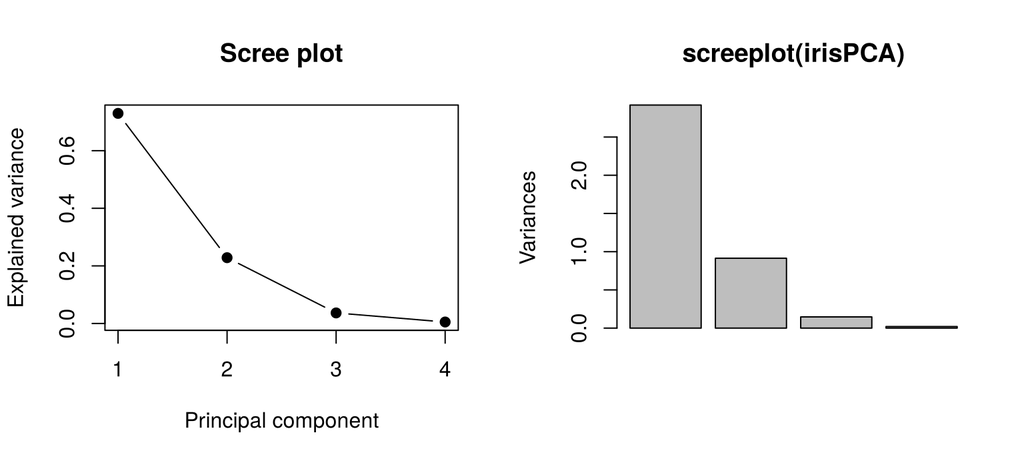

```r
x <- summary(irisPCA)
par(mfrow = c(1, 2))
plot(x$importance[2, ], xaxt = "n", type = "b", pch = 19, ylab = "Explained variance",
     xlab = "Principal component", main = "Scree plot")
axis(1, at = 1:4, labels = 1:4)
screeplot(irisPCA, type = "barplot", main = "screeplot(irisPCA)")   # the built-in version: variances
```

```r
par(mfrow = c(1, 1))
```

## D5. The component scores

```r
head(irisPCA$x)       # each flower's coordinates on the new axes (PC1 ... PC4)
```

```
##            PC1        PC2         PC3          PC4
## [1,] -2.257141 -0.4784238  0.12727962  0.024087508
## [2,] -2.074013  0.6718827  0.23382552  0.102662845
## [3,] -2.356335  0.3407664 -0.04405390  0.028282305
## [4,] -2.291707  0.5953999 -0.09098530 -0.065735340
## [5,] -2.381863 -0.6446757 -0.01568565 -0.035802870
## [6,] -2.068701 -1.4842053 -0.02687825  0.006586116
```

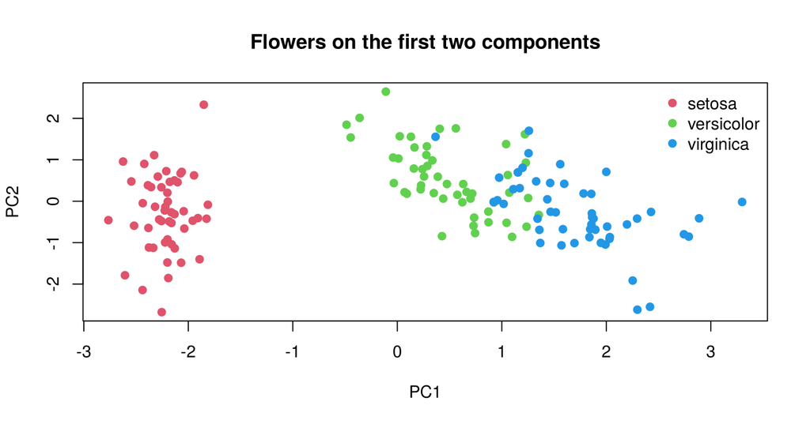

```r
plot(irisPCA$x[, 1], irisPCA$x[, 2], pch = 19, col = as.integer(iris$Species) + 1,
     xlab = "PC1", ylab = "PC2", main = "Flowers on the first two components")
legend("topright", levels(iris$Species), pch = 19, col = 2:4, bty = "n")
```

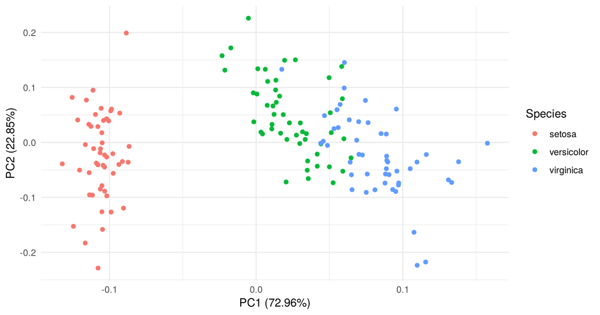

```r
df <- iris[, 1:4]
autoplot(prcomp(df, center = TRUE, scale. = TRUE), data = iris, colour = "Species") +
  theme_minimal()
```

**Bug in the sheet:** `colour ='Species’` ends with a curly quote (copied from Word/PowerPoint), which R reads as an unterminated string. Use straight quotes: `colour = "Species"`. The same happens in `main="1st PCA values”` below.

## D6. PC1 alone separates the species

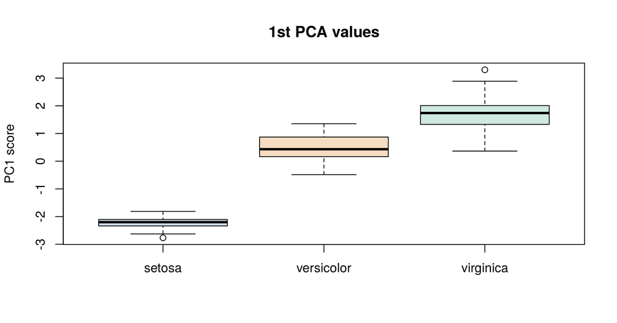

```r
boxplot(irisPCA$x[, 1] ~ iris$Species, main = "1st PCA values", col = cols,
        xlab = "", ylab = "PC1 score")
```

`irisPCA$x[, 1]` selects the column of scores on the first component. Setosa is completely separated; versicolor and virginica overlap only a little.

## D7. Biplot

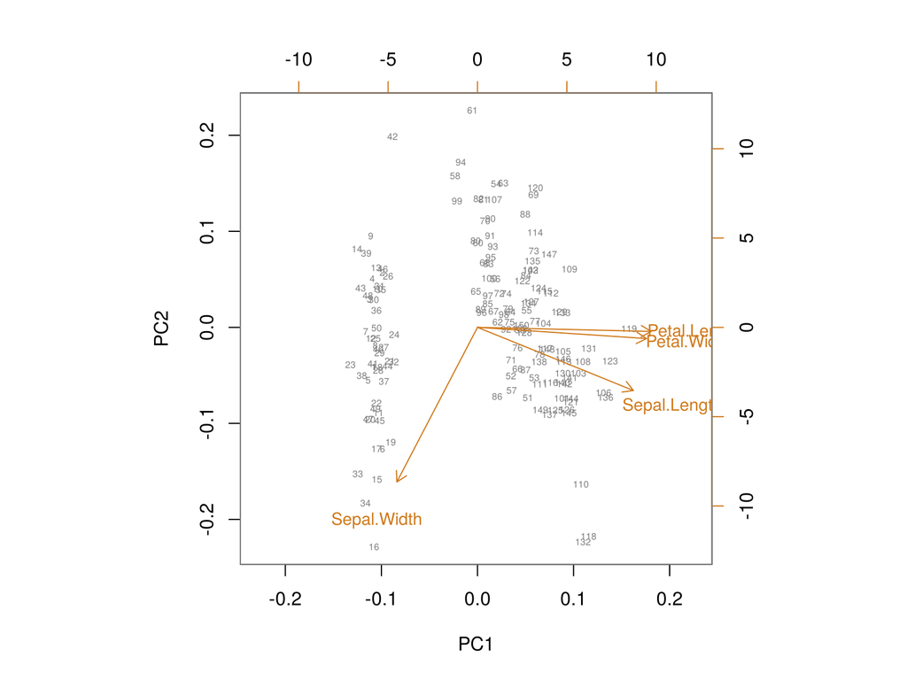

```r
biplot(irisPCA, cex = c(0.5, 0.9), col = c("grey50", "#d0791a"))
```

Points are flowers, arrows are variables. Petal length and petal width point almost along PC1: they **mostly contribute to PC1**. Sepal width points mostly along PC2.

## D8. Clustering on the components

```r
set.seed(123)
pc_km <- kmeans(irisPCA$x[, 1:2], centers = 3, nstart = 25)
table(cluster = pc_km$cluster, species = iris$Species)
```

```
##        species
## cluster setosa versicolor virginica
##       1     50          0         0
##       2      0         39        14
##       3      0         11        36
```

Clustering on two components gives the same table as clustering on all four scaled variables (Part A6), with half the dimensions.

# Summary

| Task | R |
| --- | --- |
| Standardise | `scale(df)` |
| k-means | `kmeans(x, centers = k, nstart = 25)`, `$cluster`, `$centers`, `$size`, `$tot.withinss` |
| Profile clusters | `aggregate(df, by = list(cluster = km$cluster), mean)` |
| Choose k | elbow: WSS for k = 1..10 |
| Plot clusters | `cluster::clusplot()` |
| Hierarchical | `hclust(dist(x))`, `cutree(hc, k)`, `rect.hclust()` |
| Correlations | `corrplot(cor(df), method = "number")` |
| PCA | `prcomp(df, center = TRUE, scale. = TRUE)`, `summary()`, `$rotation`, `$x` |
| PCA plots | `screeplot()`, `biplot()`, `ggfortify::autoplot(pca, data, colour)` |